# investigate-a-dataset-template

## No show data set Investigation

## Introduction

> **CONTEXT**: A person makes a doctor appointment, receives all the instructions and no-show. Who to blame?

> > > **DATA**: *PatientId* - Identification of a patient *AppointmentID* - Identification of each appointment *Gender* = Male or Female *Age* = How old is the patient. *Neighbourhood* = Where the appointment takes place. *Scholarship* = Ture of False . *Hipertension* = True or False *Diabetes* = True or False *Alcoholism* = True or False *Handcap* = True or False *SMS_received* = 1 or more messages sent to the patient. *No-show* = True or False.

```python
#importing all the nessary libraries
% autosave 10
%matplotlib inline
import pandas as pd
import matplotlib.pyplot as plt
import numpy as np
import seaborn as sns
```

```
Autosaving every 10 seconds
```

## Data Wrangling

> **Summary**: In this section of the report we verified the integrity and cleanliness of the data and made the nessary changes

### General Properties

> **1)** Taking a **first look** at the data

```python
df=pd.read_csv('C://Users//jedidiah//Downloads//Csv_data//noshowappointments-kagglev2-may-2016.csv')#reading the csv file
df.head()#print out the first few rows
```

|  | PatientId | AppointmentID | Gender | ScheduledDay | AppointmentDay | Age | Neighbourhood | Scholarship | Hipertension | Diabetes | Alcoholism | Handcap | SMS_received | No-show |
| --- | --- | --- | --- | --- | --- | --- | --- | --- | --- | --- | --- | --- | --- | --- |
| 0 | 2.987250e+13 | 5642903 | F | 2016-04-29T18:38:08Z | 2016-04-29T00:00:00Z | 62 | JARDIM DA PENHA | 0 | 1 | 0 | 0 | 0 | 0 | No |
| 1 | 5.589978e+14 | 5642503 | M | 2016-04-29T16:08:27Z | 2016-04-29T00:00:00Z | 56 | JARDIM DA PENHA | 0 | 0 | 0 | 0 | 0 | 0 | No |
| 2 | 4.262962e+12 | 5642549 | F | 2016-04-29T16:19:04Z | 2016-04-29T00:00:00Z | 62 | MATA DA PRAIA | 0 | 0 | 0 | 0 | 0 | 0 | No |
| 3 | 8.679512e+11 | 5642828 | F | 2016-04-29T17:29:31Z | 2016-04-29T00:00:00Z | 8 | PONTAL DE CAMBURI | 0 | 0 | 0 | 0 | 0 | 0 | No |
| 4 | 8.841186e+12 | 5642494 | F | 2016-04-29T16:07:23Z | 2016-04-29T00:00:00Z | 56 | JARDIM DA PENHA | 0 | 1 | 1 | 0 | 0 | 0 | No |

> **2)** checking for **ANY NULL** values in the data set

```python
print(df.shape)#command to look at the shape ie dimentions of the dataset
print(df.isnull().any())#checking for any null data point
```

```
(110527, 14)
PatientId         False
AppointmentID     False
Gender            False
ScheduledDay      False
AppointmentDay    False
Age               False
Neighbourhood     False
Scholarship       False
Hipertension      False
Diabetes          False
Alcoholism        False
Handcap           False
SMS_received      False
No-show           False
dtype: bool
```

> **3**) checking if *any* column datatype needs optimisation

```python
print(df.dtypes)#looking at the data type of each column
```

```
PatientId         float64
AppointmentID       int64
Gender             object
ScheduledDay       object
AppointmentDay     object
Age                 int64
Neighbourhood      object
Scholarship         int64
Hipertension        int64
Diabetes            int64
Alcoholism          int64
Handcap             int64
SMS_received        int64
No-show            object
dtype: object
```

## Cleaning and optimizing data

> **1)** changing **dates** to **datetime** object **2)** cleaning **handicapped** column **3)** dropping **useless** columns

```python
df['ScheduledDay'] = pd.to_datetime(df['ScheduledDay'],utc=True)#converting to datetime object
df['AppointmentDay'] = pd.to_datetime(df['AppointmentDay'],utc=True)#converting to datetime object
df.drop(['PatientId','AppointmentID'],axis=1,inplace=True)#droping the unnessary columns
p=df['Handcap'].loc[df['Handcap']>1]#removing outliers
df.drop(p.index,inplace=True)
df['no_show']=df['No-show'].replace(['No','Yes'],[0,1])#replacing'no' and 'yes' with numeric values
```

```python
print(df.dtypes)
```

```
Gender                         object
ScheduledDay      datetime64[ns, UTC]
AppointmentDay    datetime64[ns, UTC]
Age                             int64
Neighbourhood                  object
Scholarship                     int64
Hipertension                    int64
Diabetes                        int64
Alcoholism                      int64
Handcap                         int64
SMS_received                    int64
No-show                        object
no_show                         int64
dtype: object
```

## Exploratory Data Analysis

```python
df.describe()#to find numeric attributes of the dataset
```

|  | Age | Scholarship | Hipertension | Diabetes | Alcoholism | Handcap | SMS_received | no_show |
| --- | --- | --- | --- | --- | --- | --- | --- | --- |
| count | 110328.000000 | 110328.000000 | 110328.000000 | 110328.000000 | 110328.000000 | 110328.000000 | 110328.000000 | 110328.000000 |
| mean | 37.070408 | 0.098280 | 0.196831 | 0.071605 | 0.030382 | 0.018508 | 0.321179 | 0.201925 |
| std | 23.098231 | 0.297694 | 0.397606 | 0.257833 | 0.171637 | 0.134781 | 0.466931 | 0.401438 |
| min | -1.000000 | 0.000000 | 0.000000 | 0.000000 | 0.000000 | 0.000000 | 0.000000 | 0.000000 |
| 25% | 18.000000 | 0.000000 | 0.000000 | 0.000000 | 0.000000 | 0.000000 | 0.000000 | 0.000000 |
| 50% | 37.000000 | 0.000000 | 0.000000 | 0.000000 | 0.000000 | 0.000000 | 0.000000 | 0.000000 |
| 75% | 55.000000 | 0.000000 | 0.000000 | 0.000000 | 0.000000 | 0.000000 | 1.000000 | 0.000000 |
| max | 115.000000 | 1.000000 | 1.000000 | 1.000000 | 1.000000 | 1.000000 | 1.000000 | 1.000000 |

## Probable questions

> **1)** Dose the gender have any effect on the paitent not showing up? **2)** Dose having **Diabetes,shcolarship,hipertention** cause the paitent to be **more serious** about their health's and thus **show up more** than the one's who are **not** suffering form it ?

## Getting a numeric count of each the probable columns

```python
print(df['Scholarship'].value_counts())#counting number of people with and without scholarship
```

```
0    99485
1    10843
Name: Scholarship, dtype: int64
```

```python
print(df['SMS_received'].value_counts())#counting number of  people who received and did not receive an sms
```

```
0    74893
1    35435
Name: SMS_received, dtype: int64
```

```python
print(df['Gender'].value_counts())#counting the male and female breakdown
```

```
F    71731
M    38597
Name: Gender, dtype: int64
```

```python
print(df['No-show'].value_counts())#counting people who did not show up and showed up to their appointments
```

```
No     88050
Yes    22278
Name: No-show, dtype: int64
```

## General Visualisation

> In this step we take a look and the cleaned and wrangled data to get a jist of what is the general properties form the numbers calculated in the above cell

> **1)** As seen form the graphs below it seems that mostly **WOMEN** vist the hospital **2)** Most did **NOT** suffer form alcholism **3)** Most were **NOT** diabetic **4)** Most of the paietents **DID** showed up **5)** Most were **NOT** handicaped **6)** Most **DID NOT** recive a sms **7)** Most **DID NOT** have a scholarship

## Gender

> Breakdown of the genders

> > most paitentes were **female**

```
 <a list of 2 Text xticklabel objects>)
```

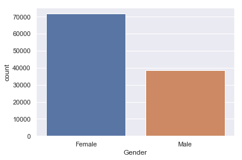

```python
sns.set(style="darkgrid")# Setting Seaborn graph style
sns.countplot(x="Gender",data=df)# using count plot method
locs, labels = plt.xticks() # finding the x label locations
plt.xticks(locs, ['Female','Male'])# replacing the x labels
```

### Age

> Shows the age distrubution of the paitentes

```
Text(0,0.5,'Count')
```

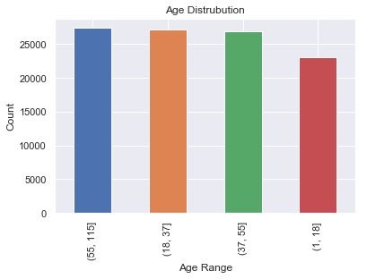

```python
o=pd.cut(df['Age'],[1,18,37,55,115])# divinding the age into groups
o.value_counts().plot.bar(title="Age Distrubution",sort_columns=True)# plotting the age groups
plt.xlabel("Age Range")# changing the x label
plt.ylabel("Count")# changing the x label
```

## Scholarship

> breakdown of no of paitents having scholarship(government aid)

> > Most **DID NOT** have a scholarship

```
 <a list of 2 Text xticklabel objects>)
```

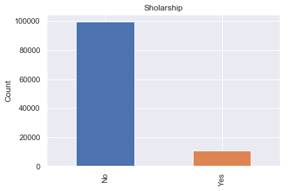

```python
df['Scholarship'].value_counts().plot.bar(title="Sholarship")# plotting the scholarship column
plt.ylabel("Count")# setting y label
plt.xticks([0,1], ['No','Yes'])# changing the x label
```

## Diabetes

> Breakdown of number of paitents suffering form **Diabetes**

> > Most paitents were **NOT** diabetic

```
 <a list of 2 Text xticklabel objects>)
```

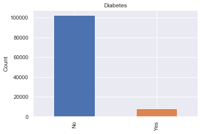

```python
df['Diabetes'].value_counts().plot.bar(title="Diabetes")# Plotting the daibetic column
plt.ylabel("Count") # changing the y label
plt.xticks([0,1], ['No','Yes'])# changing the x label
```

## Hipertention

> Breakdown of paitents having **hipertention** (Heart condition)

> > Most paitents **DID NOT** suffer form hipertention

```
 <a list of 2 Text xticklabel objects>)
```

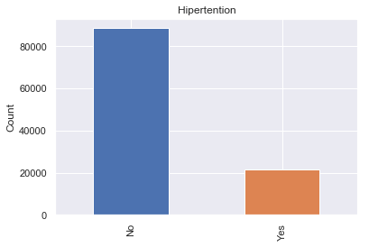

```python
df['Hipertension'].value_counts().plot.bar(title="Hipertention")# Plotting the Hipertention column
plt.ylabel("Count")# changing the y label
plt.xticks([0,1], ['No','Yes'])# changing the x label
```

## Alcoholism

> Breakdown of paitents who suffer form **alcholism**

> > Most paitents **DID NOT** suffer form **alcholism**

```
 <a list of 2 Text xticklabel objects>)
```

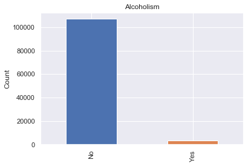

```python
df['Alcoholism'].value_counts().plot.bar(title="Alcoholism")# Plotting the Acholism column
plt.ylabel("Count")# changing the y label
plt.xticks([0,1], ['No','Yes'])# changing the x label
```

## Handicaped

> Breakdown of paitents who are **handicapped**

> > Most paitents **WERE NOT** handicapped

```
 <a list of 2 Text xticklabel objects>)
```

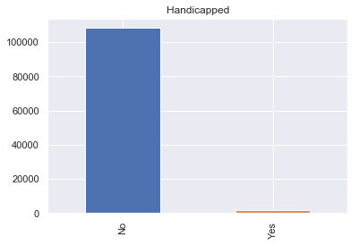

```python
#df['Handcap'].replace([0,1,2],['No','Yes','Yes'],inplace=True)
df['Handcap'].value_counts().plot.bar(title="Handicapped")#plotting the  Handicapped column
plt.xticks([0,1], ['No','Yes'])# changing the x labels
```

## SMS received

> Breakdown of people who recived **sms reminder**

> > Most people **DID NOT** receve an **SMS**

```
 <a list of 2 Text xticklabel objects>)
```

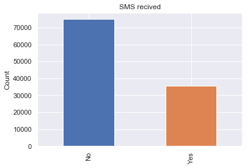

```python
df['SMS_received'].value_counts().plot.bar(title="SMS recived")# plotting sms received column
plt.ylabel("Count")# changing y labels
plt.xticks([0,1], ['No','Yes'])# changing the x label
```

# How big of a fractor dose gender play?

```
Text(0,0.5,'Count')
```

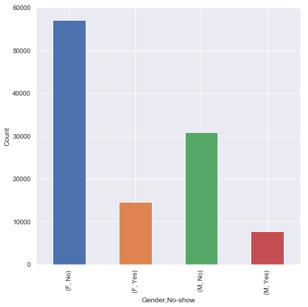

```python
g=df.groupby(['Gender','No-show'])# grouping the gender and whether the paitent showed no did not show to the appointment
g.size().plot.bar(figsize=(8,8))# plotting the data
plt.ylabel("Count")# changing y label
```

### looking into ratios

> since the ratio is almost the same meaning either gender is equally likely to show up and not show up, gender **on its own** is **most likely not** the cause

```
Text(0.5,1,'SHOW VS NO SHOW RATIOS OF EACH GENDER')
```

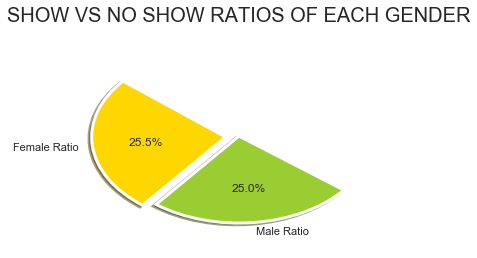

```python
k=g.size()# size of the grouped dataframe
no_female=k[0]# number of females who did not show up
yes_female=k[1]# number of females who did  show up
no_male=k[2]# number of males who did not show up
yes_male=k[3]# number of males who did  show up
explode = (0.1, 0)# piechart graphic
colors = ['gold', 'yellowgreen', 'lightcoral', 'lightskyblue']#setting the colors
plt.pie([yes_female/no_female,yes_male/no_male],explode=explode, labels=['Female Ratio','Male Ratio'], colors=colors,autopct='%1.1f%%', shadow=True, startangle=140,wedgeprops = {'linewidth': 3})#plotting the piechart with ratios
plt.title("SHOW VS NO SHOW RATIOS OF EACH GENDER",fontsize=20)# setting titles and other parameters
```

## Do people who receive an SMS more likely to not miss the appointment?

> The main aim is to figure out wether receving an sms **increses the chance** of a paitent **NOT** missing an appointment

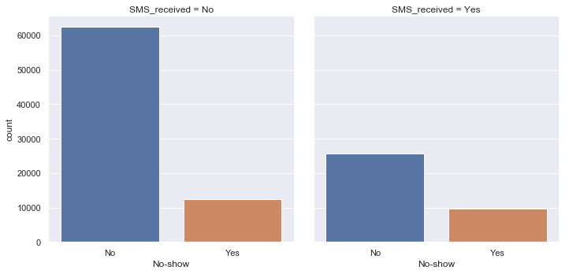

```python
df['SMS_received'].replace([0,1],['No','Yes'],inplace=True)# grouping by sms and no show
sns.catplot(x="No-show",col="SMS_received",kind="count",data=df)#using category plot
```

### 'Show' vs 'no show ratios' for each group

> looking at the graphs and the ratios it is clear that people who **DID NOT** recive an sms,**MORE** paitents **SHOWED UP** to their appointments (almost double that of the ones who recived the sms), whereas the paitents who **recived** the sms showed up in **LOWER** numbers to their appointments (nearly half of those who did not recive the sms)

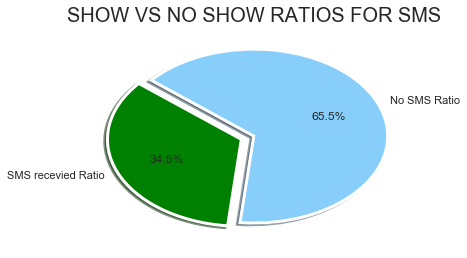

```python
sn=df.groupby(['SMS_received','No-show'])
sn=sn.size()#finding the size of grouped dataframe
rec_noshow_true=sn[3]# people who recived but did not show up
rec_show_false=sn[2]# people who recived but did show up
no_rec_noshow_true=sn[1]# people who did not recived and did not show up
no_rec_noshow_false=sn[0]# people who did not recived and did  show up
explode = (0.1, 0)#pie chart graphic
colors = ['green', 'lightskyblue']# setting chart colors
ratios=[rec_show_false/rec_noshow_true,no_rec_noshow_false/no_rec_noshow_true]# finding the ratios
plt.pie(ratios,explode=explode, labels=['SMS recevied Ratio','No SMS Ratio'], colors=colors,autopct='%1.1f%%', shadow=True, startangle=140,wedgeprops = {'linewidth': 3})# plotting the pie graph
plt.title("SHOW VS NO SHOW RATIOS FOR SMS",fontsize=20)#setting char parameters
plt.Figure(figsize=(20,20))#setting figure size
plt.show()
```

## Do people who have scholarships more likely to come to their appointments?

> in this we take a look at the people who had support form the government vs those who did not have the same support, and check if one of the either is **MOST LIKELY** to show up to the appointment

> > Looking at the graphs both seem to have **'show to no show'** numbers that are closer this time around, we will verify this by finding ratios

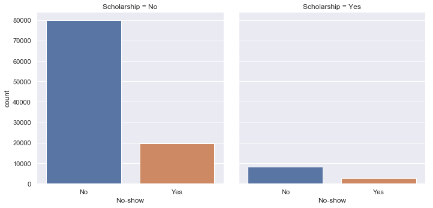

```python
df['Scholarship'].replace([0,1],['No','Yes'],inplace=True)# grouping by scholarship and no show
sns.catplot(x="No-show",col="Scholarship",kind="count",data=df)# using category plot
```

### 'Show' vs 'no show ratios' for Scholarship groups

> when we look at these ratios the ratios are **much closer** than the sms group but still the paitents who **DID NOT** have the scholarship showed up in **GREATER** numbers than the ones who **DID HAVE** the scholarship

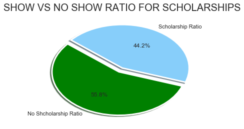

```python
schol=df.groupby(['Scholarship','No-show']).size()# finding the size of the grouped dataframe
no_schol_noshow_false=schol[0]# people with no shcolarship and did show up
no_schol_noshow_true=schol[1]# people with no shcolarship and did not show up
schol_noshow_false=schol[2]# people with shcolarship and did show up
schol_noshow_true=schol[3]# people with shcolarship and did not show up
ratios=[no_schol_noshow_false/no_schol_noshow_true,schol_noshow_false/schol_noshow_true]# finding the raitos
plt.pie(ratios,explode=explode, labels=['No Shcholarship Ratio','Scholarship Ratio'], colors=colors,autopct='%1.1f%%', shadow=True, startangle=140,wedgeprops = {'linewidth': 3})#plotting the pie chart
plt.title("SHOW VS NO SHOW RATIO FOR SCHOLARSHIPS",fontsize=20)# Setting the chart parameters
plt.Figure(figsize=(20,20))
plt.show()
```

## Dose a paitent suffering form Diabetes more unlikely to not show up?...

> In this segment we try to figure out if **diabetes** plays any role in the now show probablity

> > On taking a look at the graphs **most** paitents who **did** show up were **not diabetic**, we will again use ratios to find if that is the case

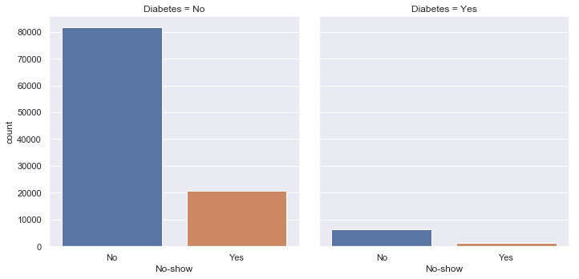

```python
df['Diabetes'].replace([0,1],['No','Yes'],inplace=True)# grouping by diabetes and no show
sns.catplot(col='Diabetes',x='No-show',kind="count",data=df)# using category plot
```

### 'Show' vs 'no show ratios' for Diabetic groups

> As seen in the ratio chart below the ratios are close but,people who **WERE DIABETIC** showed up more than the people who **DID NOT** have diabetes

> > This could mean that diabetic paitents are most likey **wont** miss an appointment

```
Text(0.5,1,'SHOW VS NO SHOW RATIO FOR DIABETIC GROUP')
```

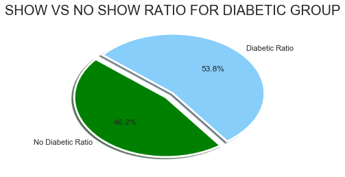

```python
k=df.groupby(['Diabetes','No-show']).size()# finding the size of grouped dataframe
no_dia_noshow_false=k[0]#people with no daibetes and did show up
no_dia_noshow_true=k[1]#people with no daibetes and did not show up
dia_noshow_false=k[2]#people with daibetes and did show up
dia_noshow_true=k[3]#people with daibetes and did not show up
ratios=[no_dia_noshow_false/no_dia_noshow_true,dia_noshow_false/dia_noshow_true]# finding the ratios
plt.pie(ratios,explode=explode, labels=['No Diabetic Ratio','Diabetic Ratio'], colors=colors,autopct='%1.1f%%', shadow=True, startangle=140,wedgeprops = {'linewidth': 3})
plt.title("SHOW VS NO SHOW RATIO FOR DIABETIC GROUP",fontsize=20)#setting the chart parameters
```

## Dose a paitent having hyper tention more likely to show up to an appointment?

> In this group we try to find if people who **have hypertention** take better care of themselfs and *not* miss appointments

> > looks like people who **DO** have hypertention show up **more** we'll verify this using ratios

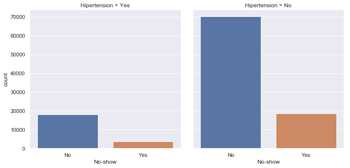

```python
df['Hipertension'].replace([0,1],['No','Yes'],inplace=True)# grouping by hipertention and no show
sns.catplot(col='Hipertension',x='No-show',kind="count",data=df)# using category plot
```

### 'Show' vs 'no show ratios' for Hipertention groups

> as seen form the chart the people **WITH** hipertention tend to show up **MORE** than the ones who dont have hipertention

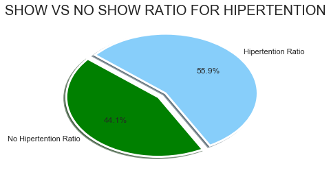

```python
k=df.groupby(['Hipertension','No-show']).size()# finding the size of the grouped dataframe
no_hiper_noshow_false=k[0]# peole with no hipertention and who did show up
no_hiper_noshow_true=k[1]# peole with no hipertention and who did not show up
hiper_noshow_false=k[2]# peole with  hipertention and who did show up
hiper_noshow_true=k[3]# peole with  hipertention and who did not show up
ratios=[no_hiper_noshow_false/no_hiper_noshow_true,hiper_noshow_false/hiper_noshow_true]# finding the ratios
plt.pie(ratios,explode=explode, labels=['No Hipertention Ratio','Hipertention Ratio'], colors=colors,autopct='%1.1f%%', shadow=True, startangle=140,wedgeprops = {'linewidth': 3})#plotting the chart
plt.title("SHOW VS NO SHOW RATIO FOR HIPERTENTION",fontsize=20)# Setting the chart parameters
plt.show()
```

## Do one of the genders more likely to miss an appointment dispite of getting an sms?

> in this section we take a took at the breakdown of the genders who **recived** an sms and those who did not and find out whether one of the genders takes the sms seriously and **shows up** more often

> > on taking a look at the bar graph both the genders who **recived** the sms showed up less often

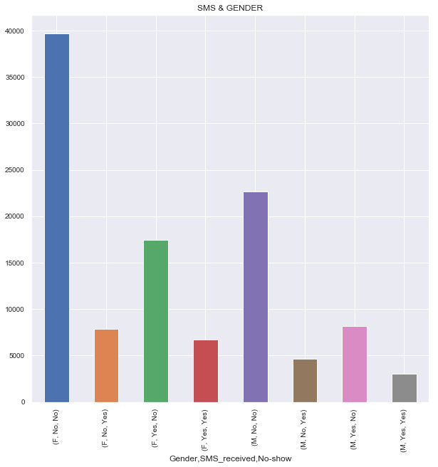

```python
l=df.groupby(['Gender','SMS_received','No-show']).size()# Grouping by gender no show and sms
l.plot.bar(figsize=(10,10),title="SMS & GENDER",fontsize=10)# plotting the dataframe using bar graph
```

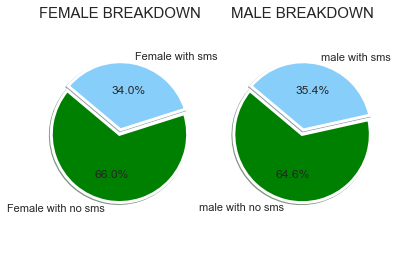

```python
l=df.groupby(['Gender','SMS_received','No-show']).size()# Finding the size of the grouped dataframe
l=dict(l)# lising the groups in a dictinary
female_ratio_nosms=l['F', 'No', 'No']/l['F', 'No', 'Yes']# show to no show ratio of females who did not recive an sms
female_ratio_sms=l['F', 'Yes', 'No']/l['F', 'Yes', 'Yes']# show to no show ratio of females who did recive an sms
male_ratio_nosms=l['M', 'No', 'No']/l['M', 'No', 'Yes']# show to no show ratio of males who did not recive an sms
male_ratio_sms=l['M', 'Yes', 'No']/l['M', 'Yes', 'Yes']# show to no show ratio of males who did  recive an sms
plt.subplot(1,2,1)# Creating an subplot
plt.pie([female_ratio_nosms,female_ratio_sms],explode=explode, labels=['Female with no sms','Female with sms'], colors=colors,autopct='%1.1f%%', shadow=True, startangle=140,wedgeprops = {'linewidth': 3},radius=1.5)#plotting the graph
plt.title('FEMALE BREAKDOWN',fontsize=15)# Setting a title
plt.axis('equal')
plt.subplot(1,2,2)
plt.pie([male_ratio_nosms,male_ratio_sms],explode=explode, labels=['male with no sms','male with sms'], colors=colors,autopct='%1.1f%%', shadow=True, startangle=140,wedgeprops = {'linewidth': 3},radius=1.5)# plotting the graph
plt.title('MALE BREAKDOWN',fontsize=15)# setting the chart parameters
plt.axis('equal')# Setting an equal axis for both the graphs
plt.show()
```

## Conclusions

> > > **LIMITATIONS**: this analysis did not perform any Stastistical tests, and the results are based on ratios, Factors such as neighbourhood's were not taken into account, the data was assumed to be accurate after thorough wrangling and inspection,The above are not the only causes other external factors were not taken into account.The corelation dose not always mean causation